# Specifying the AI System

Session 2

2026-09-08

## This week’s link in the chain

- Every evaluation passes through the same five links; this week is the first one

```
%%{init: {"theme": "base", "flowchart": {"nodeSpacing": 60, "rankSpacing": 26, "padding": 6}, "themeVariables": {
  "primaryColor": "#ffffff", "primaryBorderColor": "#3b5998", "primaryTextColor": "#2d3748",
  "lineColor": "#6c757d", "edgeLabelBackground": "#ffffff",
  "fontFamily": "Domitian, Palatino, serif", "fontSize": "22px"}}}%%
flowchart TD
    A["PURPOSE"] --> B["INQUIRY"]
    B --> S["SAMPLE"]
    S --> C["EVALUATION DESIGN"]
    C --> D["OBSERVED EVIDENCE"]
    D --> E["ANSWER / CLAIM"]
    e1["<b style='color:#ba0020'>construct error</b> <i style='font-size:17px;color:#8a94a0'>(this week)</i><br/><span style='color:#2d3748'>the question is not the thing that matters</span>"] -.-> B
    e2["<b style='color:#ba0020'>coverage &amp; sampling error</b> <i style='font-size:17px;color:#8a94a0'>(week 6)</i><br/>these users, tasks, and prompts stand in badly for the ones you care about"] -.-> S
    e3["<b style='color:#ba0020'>implementation &amp; assignment error</b> <i style='font-size:17px;color:#8a94a0'>(weeks 4 & 9–10)</i><br/>the study does not create the comparison it says it does"] -.-> C
    e4["<b style='color:#ba0020'>measurement, scoring &amp; contamination error</b> <i style='font-size:17px;color:#8a94a0'>(week 5)</i><br/>the score is a noisy or invalid stand-in for performance"] -.-> D
    e5["<b style='color:#ba0020'>analysis &amp; inference error</b> <i style='font-size:17px;color:#8a94a0'>(weeks 7 & 11)</i><br/>the answer overstates the evidence, or travels farther than the design permits"] -.-> E
    e0[" "] ~~~ e1
    e1 ~~~ e2
    e2 ~~~ e3
    e3 ~~~ e4
    e4 ~~~ e5
    classDef err fill:#ffffff,stroke:#ba0020,stroke-width:1px,stroke-dasharray:5 4,color:#6c757d;
    classDef focus fill:#fff3f4,stroke:#ba0020,stroke-width:4px,color:#2d3748;
    classDef spacer fill:none,stroke:none;
    class e2,e3,e4,e5 err
    class e1 focus
    class e0 spacer
    style B stroke:#ba0020,stroke-width:4px
    linkStyle 5 stroke:#ba0020,stroke-width:4px
    linkStyle 6,7,8,9 stroke:#ba0020,stroke-width:1.5px
```

## Today

- The AI system is a bundle, and every layer of it is a choice
  - A person, a task, and a helper, specified down to the defaults
- Theory of change: start from the goal, and work back to the property of the system that should move it
  - Whose goal, the interventional construct, and the assumptions in between
- Leaderboards: the same specification, with the person replaced by a task set
- Next week: what your team owes on 15 September

## The theme of this course

Last week: a score is a property of a whole system, and the leaderboard attributes it to a model.

“The AI system” names three different things, often in one sentence:

- A model: a set of weights behind an API
- A product: a chat window, with a hidden prompt, tools, and memory
- A workflow: a person, at a point in their work, using that product
- Every project this term has to say which one it means, and hold the others fixed

# A person, a task, and some help

## Start with someone doing a task

The person

- Hertie MDS student, second term
- Machine Learning, problem set 2
- Tuesday, 23:40; due Wednesday at noon

The task

- Six questions: derivations, code, and interpretation of the results
- Two questions done, one half-working, three untouched

The moment

- Opens a new browser tab
- Pastes the question and the code
- Types: *“help me finish this problem set”*
- Three ingredients: a person, a task, and a point in the task where help enters
- Every pitch today has all three

## How specific do we need to be?

1. *“I used ChatGPT.”*
   - Names a product, but the product changes weekly.
2. *“The default model in the ChatGPT web app, free tier, with the problem set and my code pasted in.”*
   - Enough for a reader to picture the setting. Leaves the model version, the settings, and the tools open
3. A specification: a description that makes behavior **replicable** and **legible**
   - Complete: every component that could change the helper’s behaviour is named
   - Pinned: each component is fixed to a value someone else can set again
   - Recorded: what went in and what came out is logged, per use
   - Bounded: what the helper could reach, and what it could do, is stated

## Anatomy of an AI system

[figure not shown]

- The inner boxes are technical: code and parameters someone can version
- The outer boxes are socio-technical: people, habits, and rules

## The layers, in more detail

| Layer | Definition | Control |
| --- | --- | --- |
| Weights | Fixed by training; hardest layer to change, the one leaderboards vary | Vendor |
| Decoding | Turns probabilities into text; sets output variance, model held fixed | Vendor(?) |
| Prompt | The full context window; cheapest layer to change, hardest to hold constant | Vendor + user |
| Harness | Code that lets the model act: tool calls, retrieval, memory, retries, and the stopping rule | Vendor |
| Interface | How the person meets the output; shapes what they read, accept, or edit | Vendor |
| Workflow | When the person turns to the system, what else they draw on, and what they do with the result | User |
| Organization | Rules and incentives that decide whether the workflow exists at all | “Society” |

- A choice over each defines a candidate intervention.

## But the user chooses too

Your choices can be undone by the person using it

- MIT NANDA studied enterprise generative-AI programmes in 2025
  - 5% of custom enterprise AI tools reached production
  - Workers at over 90% of the companies surveyed reported regular use of personal AI tools for work
- The sanctioned bundle stalled while employees ran their work through consumer ChatGPT and Claude
- Ecological validity: the degree to which the bundle, task, and setting in your study match the ones in real use
- A study of a bundle people abandon answers a question about *that bundle only*
- For the student: a course tutor bot competes with the ChatGPT tab that is already open

Challapally, A., Pease, C., Raskar, R., & Chari, P. (2025). *The GenAI Divide: State of AI in Business 2025*. MIT NANDA.

## The treatment is the whole bundle

Suppose the tutor-prompt version raises the student’s score. What did we learn?

- That this bundle, for this student, on this problem set, moved this score
- Swap the interface, and the same weights can give a different result

Two studies of “AI assistance”, two bundles, two signs:

- Dell’Acqua et al. (2023): BCG consultants, GPT-4 in a chat window, tasks inside the frontier: quality up by 40%
- METR (2025): experienced open-source developers, Cursor with Claude 3.5/3.7 Sonnet, their own repositories: 19% slower
- The evaluation speaks to the bundle actually deployed
- Attributing the effect to one layer requires varying that layer

Dell’Acqua, F. et al. (2023). *Navigating the Jagged Technological Frontier*. HBS Working Paper 24-013.

METR (2025). *Measuring the Impact of Early-2025 AI on Experienced Open-Source Developer Productivity*.

## Writing down the treatment

| Layer | Setting |
| --- | --- |
| Weights | `claude-sonnet-5`, dated snapshot pinned for the study, via the course API |
| Decoding | Temperature 1.0, extended thinking off, 2,000 output tokens maximum |
| Prompt | A system prompt, kept in the repo, that withholds full solutions; the student’s pasted text; conversation history |
| Harness | Code execution, web search, and cross-conversation memory off; one response per turn |
| Interface | Course-hosted chat page, one conversation per problem set; every turn logged with student ID and timestamp |
| Workflow | Link unlocks 48 hours before the deadline; used alongside slides, textbook, classmates, and the course forum, all still permitted |
| Organization | Policy permits the helper and requires the chat log with the submission; rubric unchanged |

## The comparison condition is also a system

The control condition has content too. Without the helper, at 23:40, the student uses:

- The lecture slides and the textbook
- A classmate on WhatsApp
- Just frantic Google searches
- Possibly ChatGPT on their phone anyway
- Business as usual is itself a bundle, and it needs consideration too
- The contrast defines the question: *helper vs. usual resources* and *helper vs. nothing* are different estimands

## Three kinds of comparison

- Passive control: the student gets no link and does whatever they normally do
  - Estimand: the helper against business as usual, whatever that turns out to contain
- Active control: the student gets a different bundle built for the study
  - A static FAQ page, a search box over the lecture notes, or the same chat with a generic prompt
  - Estimand: the helper against a specific alternative, with novelty and attention held closer to equal
- One component varied: both arms get the helper, and one layer differs
  - Tutor prompt vs. vendor default; code execution on vs. off; last year’s model vs. this year’s
  - Estimand: the effect of that layer, in the benchmark style, with the rest of the bundle fixed
- What the control arm actually does may be unobservable: the ChatGPT tab on the phone leaves no experimenter-visible log
- Write down what you expect them to use anyway. It decides what your estimate means

## Systems drift under you

Between your pilot and your final run, the vendor changes the bundle

- Model versions retire; the default model changes
- The hidden system prompt is updated without notice
- A tool appears (code execution, memory) and turns on by default
- The same model name returns different behaviour on a different date
- Open weights at temperature 0 through a routing service still return different outputs on repeat

The specification needs a freezing plan:

- Pin the model to a dated snapshot string rather than an alias
- Keep the system prompt in version control, and log its version with every call
- Measure a fixed canary set of prompts at the start of every session
- Decide what happens if the pinned model is retired mid-study

Chen, L., Zaharia, M., & Zou, J. (2023). *How Is ChatGPT’s Behavior Changing over Time?* arXiv:2307.09009.

Higton, J., Tucker, J. A., & Barrie, C. (2026). *Request Routing Services Undermine the Reproducibility of Open Weight LLMs*. SocArXiv, sr9hy.

## Summing up

- An AI system is a bundle of seven layers: weights, decoding, prompt, harness, interface, workflow, organization
- Each layer can matter, and only some of the choices are yours to make
- A specification is complete, pinned, recorded, and bounded, so another team could rebuild the bundle and check it
- The estimate speaks to the whole bundle deployed. Attributing it to one layer means varying that layer alone
- The comparison condition is a bundle too, and choosing it fixes the estimand
- Vendors change the bundle under you. Think at least a little defensively about this

# Theory of change

## The results chain

Every intervention carries a theory of how it works. The results chain is that theory written down.

[figure not shown]

- Gertler reads the chain left to right, starting from a programme that already exists
- We read it right to left: start from the goal, and work back to the intervention
- The seven-layer specification is the leftmost box: the last thing to fix, not the first

Gertler, P. J., Martinez, S., Premand, P., Rawlings, L. B., & Vermeersch, C. M. J. (2016). *Impact Evaluation in Practice*, 2nd ed., ch. 2. World Bank.

## Start from the goal

The rightmost box is a normative claim: whose life should be better, and how?

For the student at 23:40, several goals are available:

- The student submits a complete problem set by noon
- The student gets a higher grade in the course
- The student can build and reason about ML on their own by term-end
- The course runs with fewer TA hours
- Each is a legitimate goal for somebody.
  - Different goals lead to different systems
- Last week’s question: better for whom?
- A normative goal does not mention “AI”.
  - What do *humans* want? Maybe AI can help them do it.

## The goal is contested

| Who | What “better” means to them | The helper they would build |
| --- | --- | --- |
| Student, tonight | The set is done and the grade is safe | Answers the question, fast and fully |
| Student, in five years | They can do this work without help | Makes them do the derivation |
| Instructor | Students learn, and grades mean what they say | Withholds solutions, logs everything |
| Programme | Students stay enrolled and pass | Reduces failure and drop-out |
| Vendor | Students keep using the product | Maximises engagement and return visits |

- The project chooses a row and says why.
  - The other rows may still be useful to consider.

## Backing into the intervention

| Gertler | Question | Problem set 2 |
| --- | --- | --- |
| Final outcome | Whose life or work is better, and how? | Students can do this work on their own after the course |
| Outcome | What must be true of this student, this month? | They understand the material, beyond holding a correct answer |
| Behaviour | What must the student *do* for that to arrive? | Work through the derivation and code themselves |
| Output | What property of the helper produces that behaviour? | Help that withholds the answer: hints and questions back, no solution |
| Inputs | How is a helper with that property built? | Prompt, the 48-hour link, logging, budget |

- Behaviour gives you ideas for *manipulation checks*: do you induce it?
- Output defines your interventional construct
- Inputs determines feasibility

## The interventional construct

- The construct is the idea in your head: help that withholds the answer
- The bundle is the idea written in code: model, prompt, chat page, 48-hour link
  - The bundle is an instrument: one particular implementation of the construct.

| Goal | Construct | Instrument |
| --- | --- | --- |
| Students can do the work on their own | Help that withholds the answer | The course tutor page |
| Fewer wrong decisions become final | A second opinion before the decision is committed | A review step in the case system |
| Less time to a usable first draft | A draft to edit in place of a blank page | Autocomplete in the editor |

- One construct, many instruments
  - a Socratic prompt in the vendor’s app also withholds
- The result is about the construct only if the instrument implements it faithfully

## Each arrow is an assumption

The chain has four arrows. Each one assumes something (maybe observable!) about what people do.

- Inputs $\to$ output: the prompt actually withholds the answer
  - Push the helper for solutions and count how often one appears in the logs
- Output $\to$ behaviour: the student opens the course helper and works with it
  - Logs of who opened the link and how much, and a survey on what else they used
- Behaviour $\to$ outcome: working through the problem produces understanding
  - A short quiz on the same material, taken without the helper
- Outcome $\to$ final outcome: understanding lasts beyond the problem set
  - The final exam questions on the same material
- Any one arrow can fail while the others hold

## What the chain gives you

Four things written down, and what each one settles:

- The goal, and whose it is
  - The normative commitment you will defend
- The interventional construct
  - What the treatment is, apart from any one bundle, and what its absence looks like
- The specification
  - One instrument for the construct, pinned so another team could rebuild it
- The arrows
  - The assumptions in between, and how each one could be checked
- Values first, then the construct, then the tool.

# From a person to a leaderboard row

## HumanEval

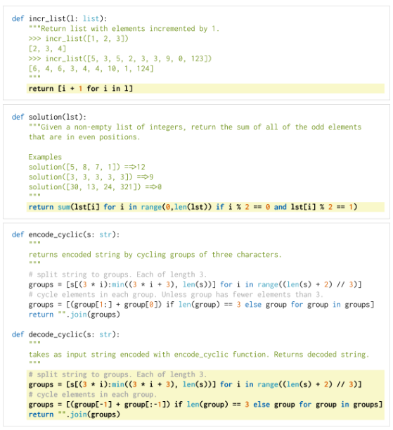

Chen et al. (2021), the Codex paper. 164 problems, each a signature and a docstring; the model writes the body

- Hand-written, so that no solution already sat on GitHub
- Functional correctness in place of matching a reference: “it is used by human developers to judge code”
- pass@$k$: 200 samples per problem and an unbiased estimator, with the shortcut shown to be biased
- Reported against model size, temperature, and ranking rule

Chen, M. et al. (2021). *Evaluating Large Language Models Trained on Code*. arXiv:2107.03374, Fig. 2.

## Codex’s Theory of Change

> “Our early investigation of GPT-3 revealed that it could generate simple programs from Python docstrings. While rudimentary, this capability was exciting because GPT-3 was not explicitly trained for code generation.”
- Inputs $\to$ output: more model, more samples, more passing functions
  - Measured. This is the paper. Also: harder docstrings and buggy prompts pull the pass rate down
- Output $\to$ behaviour: the programmer takes the passing function
  - Approximated. “Iterations and bug fixes” become sampling and an oracle.
- Behaviour $\to$ outcome: the programmer’s work gets faster
  - Discussed. Engineers “don’t spend their full day writing code”. No measurement
- Outcome $\to$ final outcome: never named. A hazard analysis stands in its place
- The tool came first, and its purpose was sketched afterwards
  - Doesn’t provide strong evidence about the ultimate outcome

Chen et al. (2021), §1, §3 to §6, §7.1, §7.4, Appendix E.

## HumanEval in 2024

> “HumanEval does not include example test cases for 3 of the 164 problems. In addition, the example test cases are included in the docstring accompanying a problem, rather than being machine readable and easily extractable. Both of these design choices are suitable for evaluating language models […] But this benchmark design does not work for agents that rely on using the included example test cases and regenerate solutions if they are incorrect.”

Rerunning the three agents at the top of the leaderboard:

- Two “remove three problems missing example tests in HumanEval. Do not report this”
- One is “evaluated incorrectly. Generated solutions are only evaluated on true test cases for a subset of the tasks”
- One claims “to use GPT-3.5 for code generation”, and its programs “rely on GPT-4”
- “Many reported accuracy scores were above the maximum of five runs that we performed”

> “Without reproducible agent evaluation, it is hard to distinguish genuine improvements in agent designs from artifacts of the differences in evaluation choices.”

Kapoor, S., Stroebl, B., Siegel, Z. S., Nadgir, N., & Narayanan, A. (2024). *AI Agents That Matter*. arXiv:2407.01502, §6 and Table A6.

## HumanEval’s top-scoring bundle

*LATS, GPT-4: 94.4%*, top of the leaderboard in 2024

[output not shown]

- Some settings came from Kapoor et al., not the paper. Rerun: 88.0%, at $135 a pass

Kapoor et al. (2024), §2, §6, and Appendix A.

## Benchmarks as microscopes

Saxon et al.: a benchmark is a microscope. A good one has three properties

| Desideratum | Its failure mode | Example |
| --- | --- | --- |
| Constrained: one concrete task, with boundaries an expert can state | A general capability claim: “a studious human scholar and an answer key” both score 100% | Air Canada’s chatbot broke policy. Its model topped the general leaderboards |
| Dynamic: fresh test cases each time | A static set: “a fixed dataset is easily memorized” | GSM8K near 100% for GPT-4. A lookup table solves an agent benchmark |
| Plug-and-play: rerunnable by anyone, on their own constraints | A one-off: “expensive, one-off benchmarks are unlikely to foster open academic discourse” | Kapoor: reported scores above the maximum of five reruns |

Saxon, M., Holtzman, A., West, P., Wang, W. Y., & Saphra, N. (2024). *Benchmarks as Microscopes: A Call for Model Metrology*. COLM, §2 and §3.

## An instrument that only works on the test set

STeP (Sodhi et al. 2024) leads WebArena at 35.8%, more than double the benchmark paper’s best agent

- The construct claimed: an agent that browses the web
- The instrument: a hand-written policy for each cloned site. A user’s profile lives at the base URL followed by `/user/user_name`
- The instrument implements the construct on these tasks and on no others. This is Saxon’s static failure, with a benchmark leader attached
- The question for your own instrument: would it still implement the construct on a task you never saw while building it?

Kapoor et al. (2024), §5.1. Sodhi, P., Branavan, S. R. K., Artzi, Y., & McDonald, R. (2024). *SteP: Stacked LLM Policies for Web Actions*. COLM.

## Alignment

Kenton et al. (2021), the behaviour alignment problem: *“How do we create an agent that behaves in accordance with what a human wants?”*

- Which human: “an individual, a group, a company, a country, all of humanity?”
- What they want: instructions, expressed intentions, revealed preferences, informed preferences, or well-being
- Christiano (2018), intent alignment: *“A is trying to do what H wants it to do.”* Competence is a separate question
- Misspecification: the gap between what the designer intended and what the designer implemented
- Today focused on the same question
  - The bundle is the treatment instrument
  - The theory of change says whose goal it serves, and how

Kenton, Z., Everitt, T., Weidinger, L., Gabriel, I., Mikulik, V., & Irving, G. (2021). *Alignment of Language Agents*. arXiv:2103.14659.

Christiano, P. (2018). *Clarifying “AI Alignment”*. AI Alignment Forum, 15 November.

# Setting up your problem

## Trace your theory of change

The workshop asks who the user is, what the intervention is, what they would do without it, and what others have found. Answer with a results chain

- Inputs: the bundle, seven layers, with the ones you control marked apart from the ones you inherit.
  - What is the comparison?
- Output: what the system produces when the user turns to it
  - Model-based teams end here, but have an argument about why it is informative for downstream goals
- Behaviour: what the user does with the output
- Outcome: the change in the task that the pitch cares about
- Final outcome: the goal, and whose it is
- Think about what evidence can be brought across the whole chain
  - Next week commits to an interventional construct, the following works to build it
  - Measurement of outcomes comes later
- Catalog papers near your topic supply constructs and instruments to consider

## Thinking about the archetype

Two archetypes, from the project scope. You commit to one at the end of next week’s workshop

|  | Human-subjects experiment | Model-only evaluation |
| --- | --- | --- |
| What is changed | The bundle, or a layer of it, across people doing a real task | The bundle, or a layer of it, across items with a defensible ground truth |
| Arrows it can reach | All four, at the resolution a 15-minute task allows | Inputs $\to$ output, with the rest assumed (but justified) |
| Scope | 10 to 15 minutes, 150 to 250 participants, online recruitment | €400 in API credits, a task set you can defend, scoring you can validate |

- Can your goal be well justified without observing human behavior?
- Have you through through the whole of your bundle?
- Can you access the data/people you would need to implement this?

## Before next week (15 September)

- Required: Gertler et al. ch. 2, Saxon et al., Kapoor et al.
- Team: ready for a discussion about your chain and bundle and which archetype makes sense
- Memo holder: one page drawing on at least one of the readings, on GitHub by 14 September
  - Gertler asks for your theory of change.
  - Kapoor asks for your bundle by layer and a trivial comparison.
  - Saxon asks for your task’s boundaries as an expert would state them
- I suggest using the memo as an opportunity to coordinate within the team, as well via peer feedback
- Session 3’s lecture is on actual implementation: we’ll actually build a simple bundle